# Introduction to Pattern Sequence based Forecasting (PSF) algorithm

Neeraj Bokde, Gualberto Asencio-Cortes and Francisco Martinez-Alvarez

2022-04-30

## Introduction

The Algorithm Pattern Sequence based Forecasting (PSF) was first proposed by Martinez Alvarez, et al., 2008 and then modified and suggested improvement by Martinez Alvarez, et al., 2011. The technical detailes are mentioned in referenced articles. PSF algorithm consists of various statistical operations like:

- Data Normalization/ Denormalization
- Calculation of optimum Window size (W)
- Calculation of optimum cluster size (k)
- Pattern Sequence based Forecasting
- RMSE/MAE Calculation, etc..

## Example

This section discusses about the examples to introduce the use of the PSF package and to compare it with auto.arima() and ets() functions, which are well accepted functions in the R community working over time series forecasting techniques. The data used in this example are ’nottem’ and ’sunspots’ which are the standard time series dataset available in R. The ’nottem’ dataset is the average air temperatures at Nottingham Castle in degrees Fahrenheit, collected for 20 years, on monthly basis.

#### Install library

Download the Package and install with instruction:

```r
library(PSF)
```

#### Model building for ’nottem’ dataset with psf() function.

```r
nottem_model <- psf(nottem)
nottem_model
```

```
## $original_series
##       Jan  Feb  Mar  Apr  May  Jun  Jul  Aug  Sep  Oct  Nov  Dec
## 1920 40.6 40.8 44.4 46.7 54.1 58.5 57.7 56.4 54.3 50.5 42.9 39.8
## 1921 44.2 39.8 45.1 47.0 54.1 58.7 66.3 59.9 57.0 54.2 39.7 42.8
## 1922 37.5 38.7 39.5 42.1 55.7 57.8 56.8 54.3 54.3 47.1 41.8 41.7
## 1923 41.8 40.1 42.9 45.8 49.2 52.7 64.2 59.6 54.4 49.2 36.3 37.6
## 1924 39.3 37.5 38.3 45.5 53.2 57.7 60.8 58.2 56.4 49.8 44.4 43.6
## 1925 40.0 40.5 40.8 45.1 53.8 59.4 63.5 61.0 53.0 50.0 38.1 36.3
## 1926 39.2 43.4 43.4 48.9 50.6 56.8 62.5 62.0 57.5 46.7 41.6 39.8
## 1927 39.4 38.5 45.3 47.1 51.7 55.0 60.4 60.5 54.7 50.3 42.3 35.2
## 1928 40.8 41.1 42.8 47.3 50.9 56.4 62.2 60.5 55.4 50.2 43.0 37.3
## 1929 34.8 31.3 41.0 43.9 53.1 56.9 62.5 60.3 59.8 49.2 42.9 41.9
## 1930 41.6 37.1 41.2 46.9 51.2 60.4 60.1 61.6 57.0 50.9 43.0 38.8
## 1931 37.1 38.4 38.4 46.5 53.5 58.4 60.6 58.2 53.8 46.6 45.5 40.6
## 1932 42.4 38.4 40.3 44.6 50.9 57.0 62.1 63.5 56.3 47.3 43.6 41.8
```

[output cut: 69 more lines]

#### Model building for ’sunspots’ dataset with psf() function.

```r
sunspots_model <- psf(sunspots)
sunspots_model
```

```
## $original_series
##        Jan   Feb   Mar   Apr   May   Jun   Jul   Aug   Sep   Oct   Nov   Dec
## 1749  58.0  62.6  70.0  55.7  85.0  83.5  94.8  66.3  75.9  75.5 158.6  85.2
## 1750  73.3  75.9  89.2  88.3  90.0 100.0  85.4 103.0  91.2  65.7  63.3  75.4
## 1751  70.0  43.5  45.3  56.4  60.7  50.7  66.3  59.8  23.5  23.2  28.5  44.0
## 1752  35.0  50.0  71.0  59.3  59.7  39.6  78.4  29.3  27.1  46.6  37.6  40.0
## 1753  44.0  32.0  45.7  38.0  36.0  31.7  22.2  39.0  28.0  25.0  20.0   6.7
## 1754   0.0   3.0   1.7  13.7  20.7  26.7  18.8  12.3   8.2  24.1  13.2   4.2
## 1755  10.2  11.2   6.8   6.5   0.0   0.0   8.6   3.2  17.8  23.7   6.8  20.0
## 1756  12.5   7.1   5.4   9.4  12.5  12.9   3.6   6.4  11.8  14.3  17.0   9.4
## 1757  14.1  21.2  26.2  30.0  38.1  12.8  25.0  51.3  39.7  32.5  64.7  33.5
## 1758  37.6  52.0  49.0  72.3  46.4  45.0  44.0  38.7  62.5  37.7  43.0  43.0
## 1759  48.3  44.0  46.8  47.0  49.0  50.0  51.0  71.3  77.2  59.7  46.3  57.0
## 1760  67.3  59.5  74.7  58.3  72.0  48.3  66.0  75.6  61.3  50.6  59.7  61.0
## 1761  70.0  91.0  80.7  71.7 107.2  99.3  94.1  91.1 100.7  88.7  89.7  46.0
```

[output cut: 266 more lines]

#### Perform predictions from trained PSF model for ’nottem’ dataset using the standard predict() function.

```r
nottem_preds <- predict(nottem_model, n.ahead = 12)
nottem_preds
```

```
##  [1] 39.10000 38.71667 42.74167 46.67500 52.68333 57.99167 62.30000 60.68333
##  [9] 57.26667 49.61667 43.35833 40.09167
```

#### Perform predictions from trained PSF model for ’sunspots’ dataset using the standard predict() function.

```r
sunspots_preds <- predict(sunspots_model, n.ahead = 48)
sunspots_preds
```

```
##  [1] 57.42000 54.33333 53.40000 56.07333 59.67333 59.22667 51.86000 50.89333
##  [9] 51.44667 44.66667 39.63333 42.39333 32.54167 37.65000 35.10833 38.84167
## [17] 30.25000 27.24167 26.63333 23.44167 24.95000 25.03333 22.91667 19.92500
## [25] 18.98750 19.82500 24.68750 15.41875 19.25625 17.51250 17.21250 20.61875
## [33] 14.03750 14.90625 21.43125 16.08125 14.47222 13.83333 13.66111 11.93889
## [41] 15.02222 14.21111 10.82778 13.93333 13.39444 18.74444 19.18889 18.83333
```

To represent the prediction performance in plot format, the plot() function is used as shown in the following code.

#### Plot for ‘nottem’ dataset

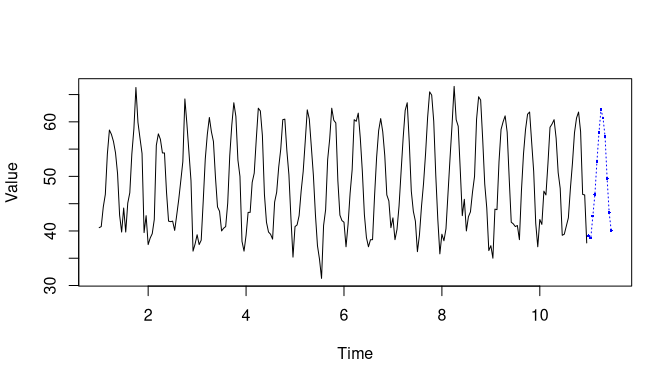

```r
plot(nottem_model, nottem_preds)
```

#### Plot for ‘sunspots’ dataset

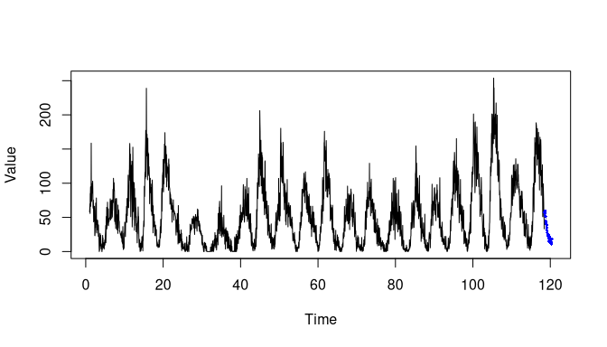

```r
plot(sunspots_model, sunspots_preds)
```

## Comparison of `psf()` with `auto.arima()` and `ets()` functions:

Example below shows the comparisons for `psf()`, `auto.arima()` and `ets()` functions when using the Root Mean Square Error (RMSE) parameter as metric, for ’sunspots’ dataset. In order to avail more accurate and robust comparison results, error values are calculated for 5 times and the mean value of error values for methods under comparison are also shown. These values clearly state that ‘psf()’ function is able to outperform the comparative time series prediction methods. Additionally, the reader might want to refer to the results published in the original work Martinez Alvarez et al. (2011), in which it was shown that PSF outperformed many different methods when applied to electricity prices and demand forecasting.

```r
library(PSF)
library(forecast)
options(warn=-1)

## Consider data `sunspots` with removal of last years's readings
# Training Data
train <- sunspots[1:2772]

# Test Data
test <- sunspots[2773:2820]

PSF <- NULL
ARIMA <- NULL
ETS <- NULL

for(i in 1:5)
{
  set.seed(i)

  # for PSF
  psf_model <- psf(train)
  a <- predict(psf_model, n.ahead = 48)

  # for ARIMA
  b <- forecast(auto.arima(train), 48)$mean

  # for ets
  c <- as.numeric(forecast(ets(train), 48)$mean)

  ## For Error Calculations
  # Error for PSF
  PSF[i] <- sqrt(mean((test - a)^2))
  # Error for ARIMA
  ARIMA[i] <- sqrt(mean((test - b)^2))
  # Error for ETS
  ETS[i] <- sqrt(mean((test - c)^2))

}

## Error values for PSF
  PSF
```

```
## [1] 61.08512 61.08512 61.08512 61.08512 61.08512
```

```r
  mean(PSF)
```

```
## [1] 61.08512
```

```r
## Error values for ARIMA
  ARIMA
```

```
## [1] 103.0719 103.0719 103.0719 103.0719 103.0719
```

```r
  mean(ARIMA)
```

```
## [1] 103.0719
```

```r
## Error values for ETS
  ETS
```

```
## [1] 70.66647 70.66647 70.66647 70.66647 70.66647
```

```r
  mean(ETS)
```

```
## [1] 70.66647
```

## References

Martínez-Álvarez, F., Troncoso, A., Riquelme, J.C. and Ruiz, J.S.A., 2008, December. LBF: A labeled-based forecasting algorithm and its application to electricity price time series. In Data Mining, 2008. ICDM’08. Eighth IEEE International Conference on (pp. 453-461). IEEE.

Martinez Alvarez, F., Troncoso, A., Riquelme, J.C. and Aguilar Ruiz, J.S., 2011. Energy time series forecasting based on pattern sequence similarity. Knowledge and Data Engineering, IEEE Transactions on, 23(8), pp.1230-1243.